# Analysing the Titanic Passengers Data

## Taking a look at the data itself : Let's try and answer the following questions.

1. What demographics made it possible for the passengers to survive?
2. How did being a male or a female affect survival? What numbers of men and women survived?
3. Were survivors from a higher class?
4. Did having siblings and parents in the ship affect survival?

```python
import numpy as np
import pandas as pd
import matplotlib as mt
import seaborn as sn
```

```python
titanic = pd.read_csv("titanic_data.csv")
titanic
```

|  | PassengerId | Survived | Pclass | Name | Sex | Age | SibSp | Parch | Ticket | Fare | Cabin | Embarked |
| --- | --- | --- | --- | --- | --- | --- | --- | --- | --- | --- | --- | --- |
| 0 | 1 | 0 | 3 | Braund, Mr. Owen Harris | male | 22.0 | 1 | 0 | A/5 21171 | 7.2500 | NaN | S |
| 1 | 2 | 1 | 1 | Cumings, Mrs. John Bradley (Florence Briggs Th... | female | 38.0 | 1 | 0 | PC 17599 | 71.2833 | C85 | C |
| 2 | 3 | 1 | 3 | Heikkinen, Miss. Laina | female | 26.0 | 0 | 0 | STON/O2. 3101282 | 7.9250 | NaN | S |
| 3 | 4 | 1 | 1 | Futrelle, Mrs. Jacques Heath (Lily May Peel) | female | 35.0 | 1 | 0 | 113803 | 53.1000 | C123 | S |
| 4 | 5 | 0 | 3 | Allen, Mr. William Henry | male | 35.0 | 0 | 0 | 373450 | 8.0500 | NaN | S |
| 5 | 6 | 0 | 3 | Moran, Mr. James | male | NaN | 0 | 0 | 330877 | 8.4583 | NaN | Q |
| 6 | 7 | 0 | 1 | McCarthy, Mr. Timothy J | male | 54.0 | 0 | 0 | 17463 | 51.8625 | E46 | S |
| 7 | 8 | 0 | 3 | Palsson, Master. Gosta Leonard | male | 2.0 | 3 | 1 | 349909 | 21.0750 | NaN | S |
| 8 | 9 | 1 | 3 | Johnson, Mrs. Oscar W (Elisabeth Vilhelmina Berg) | female | 27.0 | 0 | 2 | 347742 | 11.1333 | NaN | S |
| 9 | 10 | 1 | 2 | Nasser, Mrs. Nicholas (Adele Achem) | female | 14.0 | 1 | 0 | 237736 | 30.0708 | NaN | C |
| 10 | 11 | 1 | 3 | Sandstrom, Miss. Marguerite Rut | female | 4.0 | 1 | 1 | PP 9549 | 16.7000 | G6 | S |
| 11 | 12 | 1 | 1 | Bonnell, Miss. Elizabeth | female | 58.0 | 0 | 0 | 113783 | 26.5500 | C103 | S |
| 12 | 13 | 0 | 3 | Saundercock, Mr. William Henry | male | 20.0 | 0 | 0 | A/5. 2151 | 8.0500 | NaN | S |
| 13 | 14 | 0 | 3 | Andersson, Mr. Anders Johan | male | 39.0 | 1 | 5 | 347082 | 31.2750 | NaN | S |
| 14 | 15 | 0 | 3 | Vestrom, Miss. Hulda Amanda Adolfina | female | 14.0 | 0 | 0 | 350406 | 7.8542 | NaN | S |
| 15 | 16 | 1 | 2 | Hewlett, Mrs. (Mary D Kingcome) | female | 55.0 | 0 | 0 | 248706 | 16.0000 | NaN | S |
| 16 | 17 | 0 | 3 | Rice, Master. Eugene | male | 2.0 | 4 | 1 | 382652 | 29.1250 | NaN | Q |
| 17 | 18 | 1 | 2 | Williams, Mr. Charles Eugene | male | NaN | 0 | 0 | 244373 | 13.0000 | NaN | S |
| 18 | 19 | 0 | 3 | Vander Planke, Mrs. Julius (Emelia Maria Vande... | female | 31.0 | 1 | 0 | 345763 | 18.0000 | NaN | S |
| 19 | 20 | 1 | 3 | Masselmani, Mrs. Fatima | female | NaN | 0 | 0 | 2649 | 7.2250 | NaN | C |
| 20 | 21 | 0 | 2 | Fynney, Mr. Joseph J | male | 35.0 | 0 | 0 | 239865 | 26.0000 | NaN | S |
| 21 | 22 | 1 | 2 | Beesley, Mr. Lawrence | male | 34.0 | 0 | 0 | 248698 | 13.0000 | D56 | S |
| 22 | 23 | 1 | 3 | McGowan, Miss. Anna "Annie" | female | 15.0 | 0 | 0 | 330923 | 8.0292 | NaN | Q |
| 23 | 24 | 1 | 1 | Sloper, Mr. William Thompson | male | 28.0 | 0 | 0 | 113788 | 35.5000 | A6 | S |
| 24 | 25 | 0 | 3 | Palsson, Miss. Torborg Danira | female | 8.0 | 3 | 1 | 349909 | 21.0750 | NaN | S |
| 25 | 26 | 1 | 3 | Asplund, Mrs. Carl Oscar (Selma Augusta Emilia... | female | 38.0 | 1 | 5 | 347077 | 31.3875 | NaN | S |
| 26 | 27 | 0 | 3 | Emir, Mr. Farred Chehab | male | NaN | 0 | 0 | 2631 | 7.2250 | NaN | C |
| 27 | 28 | 0 | 1 | Fortune, Mr. Charles Alexander | male | 19.0 | 3 | 2 | 19950 | 263.0000 | C23 C25 C27 | S |
| 28 | 29 | 1 | 3 | O'Dwyer, Miss. Ellen "Nellie" | female | NaN | 0 | 0 | 330959 | 7.8792 | NaN | Q |
| 29 | 30 | 0 | 3 | Todoroff, Mr. Lalio | male | NaN | 0 | 0 | 349216 | 7.8958 | NaN | S |
| ... | ... | ... | ... | ... | ... | ... | ... | ... | ... | ... | ... | ... |
| 861 | 862 | 0 | 2 | Giles, Mr. Frederick Edward | male | 21.0 | 1 | 0 | 28134 | 11.5000 | NaN | S |
| 862 | 863 | 1 | 1 | Swift, Mrs. Frederick Joel (Margaret Welles Ba... | female | 48.0 | 0 | 0 | 17466 | 25.9292 | D17 | S |
| 863 | 864 | 0 | 3 | Sage, Miss. Dorothy Edith "Dolly" | female | NaN | 8 | 2 | CA. 2343 | 69.5500 | NaN | S |
| 864 | 865 | 0 | 2 | Gill, Mr. John William | male | 24.0 | 0 | 0 | 233866 | 13.0000 | NaN | S |
| 865 | 866 | 1 | 2 | Bystrom, Mrs. (Karolina) | female | 42.0 | 0 | 0 | 236852 | 13.0000 | NaN | S |
| 866 | 867 | 1 | 2 | Duran y More, Miss. Asuncion | female | 27.0 | 1 | 0 | SC/PARIS 2149 | 13.8583 | NaN | C |
| 867 | 868 | 0 | 1 | Roebling, Mr. Washington Augustus II | male | 31.0 | 0 | 0 | PC 17590 | 50.4958 | A24 | S |
| 868 | 869 | 0 | 3 | van Melkebeke, Mr. Philemon | male | NaN | 0 | 0 | 345777 | 9.5000 | NaN | S |
| 869 | 870 | 1 | 3 | Johnson, Master. Harold Theodor | male | 4.0 | 1 | 1 | 347742 | 11.1333 | NaN | S |
| 870 | 871 | 0 | 3 | Balkic, Mr. Cerin | male | 26.0 | 0 | 0 | 349248 | 7.8958 | NaN | S |
| 871 | 872 | 1 | 1 | Beckwith, Mrs. Richard Leonard (Sallie Monypeny) | female | 47.0 | 1 | 1 | 11751 | 52.5542 | D35 | S |
| 872 | 873 | 0 | 1 | Carlsson, Mr. Frans Olof | male | 33.0 | 0 | 0 | 695 | 5.0000 | B51 B53 B55 | S |
| 873 | 874 | 0 | 3 | Vander Cruyssen, Mr. Victor | male | 47.0 | 0 | 0 | 345765 | 9.0000 | NaN | S |
| 874 | 875 | 1 | 2 | Abelson, Mrs. Samuel (Hannah Wizosky) | female | 28.0 | 1 | 0 | P/PP 3381 | 24.0000 | NaN | C |
| 875 | 876 | 1 | 3 | Najib, Miss. Adele Kiamie "Jane" | female | 15.0 | 0 | 0 | 2667 | 7.2250 | NaN | C |
| 876 | 877 | 0 | 3 | Gustafsson, Mr. Alfred Ossian | male | 20.0 | 0 | 0 | 7534 | 9.8458 | NaN | S |
| 877 | 878 | 0 | 3 | Petroff, Mr. Nedelio | male | 19.0 | 0 | 0 | 349212 | 7.8958 | NaN | S |
| 878 | 879 | 0 | 3 | Laleff, Mr. Kristo | male | NaN | 0 | 0 | 349217 | 7.8958 | NaN | S |
| 879 | 880 | 1 | 1 | Potter, Mrs. Thomas Jr (Lily Alexenia Wilson) | female | 56.0 | 0 | 1 | 11767 | 83.1583 | C50 | C |
| 880 | 881 | 1 | 2 | Shelley, Mrs. William (Imanita Parrish Hall) | female | 25.0 | 0 | 1 | 230433 | 26.0000 | NaN | S |
| 881 | 882 | 0 | 3 | Markun, Mr. Johann | male | 33.0 | 0 | 0 | 349257 | 7.8958 | NaN | S |
| 882 | 883 | 0 | 3 | Dahlberg, Miss. Gerda Ulrika | female | 22.0 | 0 | 0 | 7552 | 10.5167 | NaN | S |
| 883 | 884 | 0 | 2 | Banfield, Mr. Frederick James | male | 28.0 | 0 | 0 | C.A./SOTON 34068 | 10.5000 | NaN | S |
| 884 | 885 | 0 | 3 | Sutehall, Mr. Henry Jr | male | 25.0 | 0 | 0 | SOTON/OQ 392076 | 7.0500 | NaN | S |
| 885 | 886 | 0 | 3 | Rice, Mrs. William (Margaret Norton) | female | 39.0 | 0 | 5 | 382652 | 29.1250 | NaN | Q |
| 886 | 887 | 0 | 2 | Montvila, Rev. Juozas | male | 27.0 | 0 | 0 | 211536 | 13.0000 | NaN | S |
| 887 | 888 | 1 | 1 | Graham, Miss. Margaret Edith | female | 19.0 | 0 | 0 | 112053 | 30.0000 | B42 | S |
| 888 | 889 | 0 | 3 | Johnston, Miss. Catherine Helen "Carrie" | female | NaN | 1 | 2 | W./C. 6607 | 23.4500 | NaN | S |
| 889 | 890 | 1 | 1 | Behr, Mr. Karl Howell | male | 26.0 | 0 | 0 | 111369 | 30.0000 | C148 | C |
| 890 | 891 | 0 | 3 | Dooley, Mr. Patrick | male | 32.0 | 0 | 0 | 370376 | 7.7500 | NaN | Q |

891 rows × 12 columns

Opening up the data set to see what columns of data are available to be analyzed for any conclusions.

```python
titanic.head()
```

|  | PassengerId | Survived | Pclass | Name | Sex | Age | SibSp | Parch | Ticket | Fare | Cabin | Embarked |
| --- | --- | --- | --- | --- | --- | --- | --- | --- | --- | --- | --- | --- |
| 0 | 1 | 0 | 3 | Braund, Mr. Owen Harris | male | 22.0 | 1 | 0 | A/5 21171 | 7.2500 | NaN | S |
| 1 | 2 | 1 | 1 | Cumings, Mrs. John Bradley (Florence Briggs Th... | female | 38.0 | 1 | 0 | PC 17599 | 71.2833 | C85 | C |
| 2 | 3 | 1 | 3 | Heikkinen, Miss. Laina | female | 26.0 | 0 | 0 | STON/O2. 3101282 | 7.9250 | NaN | S |
| 3 | 4 | 1 | 1 | Futrelle, Mrs. Jacques Heath (Lily May Peel) | female | 35.0 | 1 | 0 | 113803 | 53.1000 | C123 | S |
| 4 | 5 | 0 | 3 | Allen, Mr. William Henry | male | 35.0 | 0 | 0 | 373450 | 8.0500 | NaN | S |

The information about various fields here from the website.

Data Dictionary

```
Variable    Definition    Key
survival    Survival    0 = No, 1 = Yes
pclass    Ticket class    1 = 1st, 2 = 2nd, 3 = 3rd
sex    Sex
Age    Age in years
sibsp    # of siblings / spouses aboard the Titanic
parch    # of parents / children aboard the Titanic
ticket    Ticket number
fare    Passenger fare
cabin    Cabin number
embarked    Port of Embarkation    C = Cherbourg, Q = Queenstown, S = Southampton
Variable Notes
```

pclass: A proxy for socio-economic status (SES) 1st = Upper 2nd = Middle 3rd = Lower

Looking at the data types in the data set for analysis

```python
titanic.dtypes
```

```
PassengerId      int64
Survived         int64
Pclass           int64
Name            object
Sex             object
Age            float64
SibSp            int64
Parch            int64
Ticket          object
Fare           float64
Cabin           object
Embarked        object
dtype: object
```

```python
ageSeries = pd.Series(titanic['Age'])
ageSeries.isnull().sum()
```

```
177
```

On looking at the age column a 177 NaNs were found. Obviously it would not make sense to have this data, as our predictions on age correlations with survivors would be skewed. Therefore we need to remove these values from the dataset. Therefore we remove the rows in the data set that has NaN values using the Age column only by selecting finite values of Age from the this Column and creating a new dataset for those with the finite values.

```python
titanic = titanic[np.isfinite(titanic['Age'])]
titanic
```

|  | PassengerId | Survived | Pclass | Name | Sex | Age | SibSp | Parch | Ticket | Fare | Cabin | Embarked |
| --- | --- | --- | --- | --- | --- | --- | --- | --- | --- | --- | --- | --- |
| 0 | 1 | 0 | 3 | Braund, Mr. Owen Harris | male | 22.0 | 1 | 0 | A/5 21171 | 7.2500 | NaN | S |
| 1 | 2 | 1 | 1 | Cumings, Mrs. John Bradley (Florence Briggs Th... | female | 38.0 | 1 | 0 | PC 17599 | 71.2833 | C85 | C |
| 2 | 3 | 1 | 3 | Heikkinen, Miss. Laina | female | 26.0 | 0 | 0 | STON/O2. 3101282 | 7.9250 | NaN | S |
| 3 | 4 | 1 | 1 | Futrelle, Mrs. Jacques Heath (Lily May Peel) | female | 35.0 | 1 | 0 | 113803 | 53.1000 | C123 | S |
| 4 | 5 | 0 | 3 | Allen, Mr. William Henry | male | 35.0 | 0 | 0 | 373450 | 8.0500 | NaN | S |
| 6 | 7 | 0 | 1 | McCarthy, Mr. Timothy J | male | 54.0 | 0 | 0 | 17463 | 51.8625 | E46 | S |
| 7 | 8 | 0 | 3 | Palsson, Master. Gosta Leonard | male | 2.0 | 3 | 1 | 349909 | 21.0750 | NaN | S |
| 8 | 9 | 1 | 3 | Johnson, Mrs. Oscar W (Elisabeth Vilhelmina Berg) | female | 27.0 | 0 | 2 | 347742 | 11.1333 | NaN | S |
| 9 | 10 | 1 | 2 | Nasser, Mrs. Nicholas (Adele Achem) | female | 14.0 | 1 | 0 | 237736 | 30.0708 | NaN | C |
| 10 | 11 | 1 | 3 | Sandstrom, Miss. Marguerite Rut | female | 4.0 | 1 | 1 | PP 9549 | 16.7000 | G6 | S |
| 11 | 12 | 1 | 1 | Bonnell, Miss. Elizabeth | female | 58.0 | 0 | 0 | 113783 | 26.5500 | C103 | S |
| 12 | 13 | 0 | 3 | Saundercock, Mr. William Henry | male | 20.0 | 0 | 0 | A/5. 2151 | 8.0500 | NaN | S |
| 13 | 14 | 0 | 3 | Andersson, Mr. Anders Johan | male | 39.0 | 1 | 5 | 347082 | 31.2750 | NaN | S |
| 14 | 15 | 0 | 3 | Vestrom, Miss. Hulda Amanda Adolfina | female | 14.0 | 0 | 0 | 350406 | 7.8542 | NaN | S |
| 15 | 16 | 1 | 2 | Hewlett, Mrs. (Mary D Kingcome) | female | 55.0 | 0 | 0 | 248706 | 16.0000 | NaN | S |
| 16 | 17 | 0 | 3 | Rice, Master. Eugene | male | 2.0 | 4 | 1 | 382652 | 29.1250 | NaN | Q |
| 18 | 19 | 0 | 3 | Vander Planke, Mrs. Julius (Emelia Maria Vande... | female | 31.0 | 1 | 0 | 345763 | 18.0000 | NaN | S |
| 20 | 21 | 0 | 2 | Fynney, Mr. Joseph J | male | 35.0 | 0 | 0 | 239865 | 26.0000 | NaN | S |
| 21 | 22 | 1 | 2 | Beesley, Mr. Lawrence | male | 34.0 | 0 | 0 | 248698 | 13.0000 | D56 | S |
| 22 | 23 | 1 | 3 | McGowan, Miss. Anna "Annie" | female | 15.0 | 0 | 0 | 330923 | 8.0292 | NaN | Q |
| 23 | 24 | 1 | 1 | Sloper, Mr. William Thompson | male | 28.0 | 0 | 0 | 113788 | 35.5000 | A6 | S |
| 24 | 25 | 0 | 3 | Palsson, Miss. Torborg Danira | female | 8.0 | 3 | 1 | 349909 | 21.0750 | NaN | S |
| 25 | 26 | 1 | 3 | Asplund, Mrs. Carl Oscar (Selma Augusta Emilia... | female | 38.0 | 1 | 5 | 347077 | 31.3875 | NaN | S |
| 27 | 28 | 0 | 1 | Fortune, Mr. Charles Alexander | male | 19.0 | 3 | 2 | 19950 | 263.0000 | C23 C25 C27 | S |
| 30 | 31 | 0 | 1 | Uruchurtu, Don. Manuel E | male | 40.0 | 0 | 0 | PC 17601 | 27.7208 | NaN | C |
| 33 | 34 | 0 | 2 | Wheadon, Mr. Edward H | male | 66.0 | 0 | 0 | C.A. 24579 | 10.5000 | NaN | S |
| 34 | 35 | 0 | 1 | Meyer, Mr. Edgar Joseph | male | 28.0 | 1 | 0 | PC 17604 | 82.1708 | NaN | C |
| 35 | 36 | 0 | 1 | Holverson, Mr. Alexander Oskar | male | 42.0 | 1 | 0 | 113789 | 52.0000 | NaN | S |
| 37 | 38 | 0 | 3 | Cann, Mr. Ernest Charles | male | 21.0 | 0 | 0 | A./5. 2152 | 8.0500 | NaN | S |
| 38 | 39 | 0 | 3 | Vander Planke, Miss. Augusta Maria | female | 18.0 | 2 | 0 | 345764 | 18.0000 | NaN | S |
| ... | ... | ... | ... | ... | ... | ... | ... | ... | ... | ... | ... | ... |
| 856 | 857 | 1 | 1 | Wick, Mrs. George Dennick (Mary Hitchcock) | female | 45.0 | 1 | 1 | 36928 | 164.8667 | NaN | S |
| 857 | 858 | 1 | 1 | Daly, Mr. Peter Denis | male | 51.0 | 0 | 0 | 113055 | 26.5500 | E17 | S |
| 858 | 859 | 1 | 3 | Baclini, Mrs. Solomon (Latifa Qurban) | female | 24.0 | 0 | 3 | 2666 | 19.2583 | NaN | C |
| 860 | 861 | 0 | 3 | Hansen, Mr. Claus Peter | male | 41.0 | 2 | 0 | 350026 | 14.1083 | NaN | S |
| 861 | 862 | 0 | 2 | Giles, Mr. Frederick Edward | male | 21.0 | 1 | 0 | 28134 | 11.5000 | NaN | S |
| 862 | 863 | 1 | 1 | Swift, Mrs. Frederick Joel (Margaret Welles Ba... | female | 48.0 | 0 | 0 | 17466 | 25.9292 | D17 | S |
| 864 | 865 | 0 | 2 | Gill, Mr. John William | male | 24.0 | 0 | 0 | 233866 | 13.0000 | NaN | S |
| 865 | 866 | 1 | 2 | Bystrom, Mrs. (Karolina) | female | 42.0 | 0 | 0 | 236852 | 13.0000 | NaN | S |
| 866 | 867 | 1 | 2 | Duran y More, Miss. Asuncion | female | 27.0 | 1 | 0 | SC/PARIS 2149 | 13.8583 | NaN | C |
| 867 | 868 | 0 | 1 | Roebling, Mr. Washington Augustus II | male | 31.0 | 0 | 0 | PC 17590 | 50.4958 | A24 | S |
| 869 | 870 | 1 | 3 | Johnson, Master. Harold Theodor | male | 4.0 | 1 | 1 | 347742 | 11.1333 | NaN | S |
| 870 | 871 | 0 | 3 | Balkic, Mr. Cerin | male | 26.0 | 0 | 0 | 349248 | 7.8958 | NaN | S |
| 871 | 872 | 1 | 1 | Beckwith, Mrs. Richard Leonard (Sallie Monypeny) | female | 47.0 | 1 | 1 | 11751 | 52.5542 | D35 | S |
| 872 | 873 | 0 | 1 | Carlsson, Mr. Frans Olof | male | 33.0 | 0 | 0 | 695 | 5.0000 | B51 B53 B55 | S |
| 873 | 874 | 0 | 3 | Vander Cruyssen, Mr. Victor | male | 47.0 | 0 | 0 | 345765 | 9.0000 | NaN | S |
| 874 | 875 | 1 | 2 | Abelson, Mrs. Samuel (Hannah Wizosky) | female | 28.0 | 1 | 0 | P/PP 3381 | 24.0000 | NaN | C |
| 875 | 876 | 1 | 3 | Najib, Miss. Adele Kiamie "Jane" | female | 15.0 | 0 | 0 | 2667 | 7.2250 | NaN | C |
| 876 | 877 | 0 | 3 | Gustafsson, Mr. Alfred Ossian | male | 20.0 | 0 | 0 | 7534 | 9.8458 | NaN | S |
| 877 | 878 | 0 | 3 | Petroff, Mr. Nedelio | male | 19.0 | 0 | 0 | 349212 | 7.8958 | NaN | S |
| 879 | 880 | 1 | 1 | Potter, Mrs. Thomas Jr (Lily Alexenia Wilson) | female | 56.0 | 0 | 1 | 11767 | 83.1583 | C50 | C |
| 880 | 881 | 1 | 2 | Shelley, Mrs. William (Imanita Parrish Hall) | female | 25.0 | 0 | 1 | 230433 | 26.0000 | NaN | S |
| 881 | 882 | 0 | 3 | Markun, Mr. Johann | male | 33.0 | 0 | 0 | 349257 | 7.8958 | NaN | S |
| 882 | 883 | 0 | 3 | Dahlberg, Miss. Gerda Ulrika | female | 22.0 | 0 | 0 | 7552 | 10.5167 | NaN | S |
| 883 | 884 | 0 | 2 | Banfield, Mr. Frederick James | male | 28.0 | 0 | 0 | C.A./SOTON 34068 | 10.5000 | NaN | S |
| 884 | 885 | 0 | 3 | Sutehall, Mr. Henry Jr | male | 25.0 | 0 | 0 | SOTON/OQ 392076 | 7.0500 | NaN | S |
| 885 | 886 | 0 | 3 | Rice, Mrs. William (Margaret Norton) | female | 39.0 | 0 | 5 | 382652 | 29.1250 | NaN | Q |
| 886 | 887 | 0 | 2 | Montvila, Rev. Juozas | male | 27.0 | 0 | 0 | 211536 | 13.0000 | NaN | S |
| 887 | 888 | 1 | 1 | Graham, Miss. Margaret Edith | female | 19.0 | 0 | 0 | 112053 | 30.0000 | B42 | S |
| 889 | 890 | 1 | 1 | Behr, Mr. Karl Howell | male | 26.0 | 0 | 0 | 111369 | 30.0000 | C148 | C |
| 890 | 891 | 0 | 3 | Dooley, Mr. Patrick | male | 32.0 | 0 | 0 | 370376 | 7.7500 | NaN | Q |

714 rows × 12 columns

Checking number of survivors and the total number of passengers , to get an Idea of survivor:passenger ratio

```python
titanic.shape
```

```
(714, 12)
```

Now that the data set has been cleaned of the NaN values in age we can perform some stats.

```python
titanic['Survived'].sum()
```

```
290
```

```python
ratio  = 342.0/ 891.0
print ratio
```

```
0.383838383838
```

Close to 40% survived.

```python
zero_ten_total = np.where((titanic['Age'] > 0) & (titanic['Age'] <= 10))
zero_ten_survive = np.where((titanic['Age'] > 0) & (titanic['Age'] <= 10) & (titanic['Survived'] == 1))
ten_twe_total = np.where((titanic['Age'] > 10) & (titanic['Age'] <= 20))
ten_twe_survive = np.where((titanic['Age'] > 10) & (titanic['Age'] <= 20) & (titanic['Survived'] == 1))
twe_thir_total = np.where((titanic['Age'] > 20) & (titanic['Age'] <= 30))
twe_thir_survive = np.where((titanic['Age'] > 20) & (titanic['Age'] <= 30) & (titanic['Survived'] == 1))
thir_for_total = np.where((titanic['Age'] > 30) & (titanic['Age'] <= 40))
thir_for_survive = np.where((titanic['Age'] > 30) & (titanic['Age'] <= 40) & (titanic['Survived'] == 1))
for_fif_total = np.where((titanic['Age'] > 40) & (titanic['Age'] <= 50))
for_fif_survive = np.where((titanic['Age'] > 40) & (titanic['Age'] <= 50) & (titanic['Survived'] == 1))
fif_plus_total = np.where((titanic['Age'] > 50))
fif_plus_survive = np.where((titanic['Age'] > 50) & (titanic['Survived'] == 1))

print "0-10 survivors %", 100*float(np.count_nonzero(zero_ten_survive))/np.count_nonzero(zero_ten_total)
print "10-20 survivors %", 100*float(np.count_nonzero(ten_twe_survive))/np.count_nonzero(ten_twe_total)
print "20-30 survivors %", 100*float(np.count_nonzero(twe_thir_survive))/np.count_nonzero(twe_thir_total)
print "30-40 survivors %", 100*float(np.count_nonzero(thir_for_survive))/np.count_nonzero(thir_for_total)
print "40-50 survivors %", 100*float(np.count_nonzero(for_fif_survive))/np.count_nonzero(for_fif_total)
print "50+ survivors %", 100*float(np.count_nonzero(fif_plus_survive))/np.count_nonzero(fif_plus_total)
```

```
0-10 survivors % 59.375
10-20 survivors % 38.2608695652
20-30 survivors % 36.6812227074
30-40 survivors % 44.5161290323
40-50 survivors % 38.3720930233
50+ survivors % 34.375
```

Let's try and look at the various correlations for the survivors and the non survivors by first writing a correlation function and then applying it to various variables.

```python
def correlation(x, y):
    meanx = x.mean()
    meany = y.mean()
    newx = (x - meanx) / x.std(ddof=0)
    newy = (y - meany) / y.std(ddof=0)
    corr = (newx * newy).mean()
    return corr
```

```python
ageAndSurviveCorr = correlation(titanic['Age'], titanic['Survived'])
PclassAndSurviveCorr= correlation(titanic['Pclass'], titanic['Survived'])
ParentAndSurviveCorr = correlation(titanic['Parch'], titanic['Survived'])
SiblingsAndSurviveCorr = correlation(titanic['SibSp'], titanic['Survived'])
print ageAndSurviveCorr , ' : Age and Survive Corr'
print PclassAndSurviveCorr, ' : Class and Survive Corr'
print ParentAndSurviveCorr, ' : Parents and Survive Corr'
print SiblingsAndSurviveCorr, ': Siblings and Survive Corr'
```

```
-0.0772210945722  : Age and Survive Corr
-0.359652682087  : Class and Survive Corr
0.0933170077422  : Parents and Survive Corr
-0.0173583604795 : Siblings and Survive Corr
```

In order to do a correlation study between sex and survival it would make sense to convert sex into a binary and then add this to the original data set. I changed 'male' to 1 and 'female' to 0.

```python
newTitanic = titanic.replace(to_replace =['male', 'female'],value =[1.0,0.0])

newTitanic.head()
```

|  | PassengerId | Survived | Pclass | Name | Sex | Age | SibSp | Parch | Ticket | Fare | Cabin | Embarked |
| --- | --- | --- | --- | --- | --- | --- | --- | --- | --- | --- | --- | --- |
| 0 | 1 | 0 | 3 | Braund, Mr. Owen Harris | 1.0 | 22.0 | 1 | 0 | A/5 21171 | 7.2500 | NaN | S |
| 1 | 2 | 1 | 1 | Cumings, Mrs. John Bradley (Florence Briggs Th... | 0.0 | 38.0 | 1 | 0 | PC 17599 | 71.2833 | C85 | C |
| 2 | 3 | 1 | 3 | Heikkinen, Miss. Laina | 0.0 | 26.0 | 0 | 0 | STON/O2. 3101282 | 7.9250 | NaN | S |
| 3 | 4 | 1 | 1 | Futrelle, Mrs. Jacques Heath (Lily May Peel) | 0.0 | 35.0 | 1 | 0 | 113803 | 53.1000 | C123 | S |
| 4 | 5 | 0 | 3 | Allen, Mr. William Henry | 1.0 | 35.0 | 0 | 0 | 373450 | 8.0500 | NaN | S |

```python
SexAndSurviveCorr = correlation(newTitanic['Sex'], newTitanic['Survived'])
print SexAndSurviveCorr, ': Sex and Survive Corr'
```

```
-0.538825593015 : Sex and Survive Corr
```

```python
newTitanic['Sex'].sum()
```

```
453.0
```

453 out of the 714 were men.

```python
men = (float(453)/714)*100
women = 100 - 63.44

print men ,'% Men'
print women, ' % Women'
print (714 -453) , ': Number of Women'
```

```
63.4453781513 % Men
36.56  % Women
261 : Number of Women
```

Writing code to check for all Sex and Survived columns (if they both are 1, these are men that survived)

```python
newTitanic['sex&survive'] = np.where(( newTitanic['Sex'] == newTitanic['Survived']) & (newTitanic['Sex'] == 1), newTitanic['Sex'],np.nan)
newTitanic['sex&survive'].sum()
```

```
93.0
```

```python
93.0 / 453 *100
```

```
20.52980132450331
```

93 of the 453 men survived, that's a survival chance of 20.52 % for men.

Writing code to check for sex and survived if sex = 0 and survived = 1, these are women that survived)

```python
newTitanic['sex&survive2'] = np.where(( newTitanic['Sex'] == 0) & (newTitanic['Survived'] == 1), 1, np.nan)
newTitanic['sex&survive2'].sum()
```

```
197.0
```

```python
100* 197.0 / 261
```

```
75.47892720306514
```

197 of the 261 women in the data set survived, that's a survival chance of 75%.

```python
redTitanic = newTitanic.drop(newTitanic.columns[[3, 8, 10]], axis=1)

modTitanic = redTitanic.replace(to_replace = ['C', 'Q', 'S'], value = [1, 2, 3])
```

```python
modTitanic.head()
```

|  | PassengerId | Survived | Pclass | Sex | Age | SibSp | Parch | Fare | Embarked |
| --- | --- | --- | --- | --- | --- | --- | --- | --- | --- |
| 0 | 1 | 0 | 3 | 1.0 | 22.0 | 1 | 0 | 7.2500 | 3.0 |
| 1 | 2 | 1 | 1 | 0.0 | 38.0 | 1 | 0 | 71.2833 | 1.0 |
| 2 | 3 | 1 | 3 | 0.0 | 26.0 | 0 | 0 | 7.9250 | 3.0 |
| 3 | 4 | 1 | 1 | 0.0 | 35.0 | 1 | 0 | 53.1000 | 3.0 |
| 4 | 5 | 0 | 3 | 1.0 | 35.0 | 0 | 0 | 8.0500 | 3.0 |

Now that we have a reduced dataset from the original with some modifications such as sex changed to binary and embarkation value changed to number it would make sense to apply the correlation function on this.

This will give us the pairwise correlation for each variable.

```python
modTitanic.corr(method='pearson', min_periods=1)
```

|  | PassengerId | Survived | Pclass | Sex | Age | SibSp | Parch | Fare | Embarked |
| --- | --- | --- | --- | --- | --- | --- | --- | --- | --- |
| PassengerId | 1.000000 | 0.029340 | -0.035349 | 0.024575 | 0.036847 | -0.082398 | -0.011617 | 0.009592 | -0.001836 |
| Survived | 0.029340 | 1.000000 | -0.359653 | -0.538826 | -0.077221 | -0.017358 | 0.093317 | 0.268189 | -0.181979 |
| Pclass | -0.035349 | -0.359653 | 1.000000 | 0.155460 | -0.369226 | 0.067247 | 0.025683 | -0.554182 | 0.244145 |
| Sex | 0.024575 | -0.538826 | 0.155460 | 1.000000 | 0.093254 | -0.103950 | -0.246972 | -0.184994 | 0.109639 |
| Age | 0.036847 | -0.077221 | -0.369226 | 0.093254 | 1.000000 | -0.308247 | -0.189119 | 0.096067 | -0.032565 |
| SibSp | -0.082398 | -0.017358 | 0.067247 | -0.103950 | -0.308247 | 1.000000 | 0.383820 | 0.138329 | 0.033064 |
| Parch | -0.011617 | 0.093317 | 0.025683 | -0.246972 | -0.189119 | 0.383820 | 1.000000 | 0.205119 | 0.011803 |
| Fare | 0.009592 | 0.268189 | -0.554182 | -0.184994 | 0.096067 | 0.138329 | 0.205119 | 1.000000 | -0.283510 |
| Embarked | -0.001836 | -0.181979 | 0.244145 | 0.109639 | -0.032565 | 0.033064 | 0.011803 | -0.283510 | 1.000000 |

Looking at the Survived column it is immediately clear (and it confirms our previous study) :

## THE NET qualitative understanding from this would be : Higher paying women with higher class seats survived the most. It also helped positively towards survival if one was a girl of a higher class with her parents on the ship.

Next we can separate the data set into two separate sets one for survivors and one for non-survivors to get quantitative data about survival.

```python
groupSurvive = modTitanic.groupby('Survived')
```

Here we have made a group based on the key 'Survived'. Creating two groups. One with the Key 1 'group1' = Survivors and the other with the key 0, 'group 0 ' = Dead.

```python
group1 = groupSurvive.get_group(1)
group1.head()
```

|  | PassengerId | Survived | Pclass | Sex | Age | SibSp | Parch | Fare | Embarked |
| --- | --- | --- | --- | --- | --- | --- | --- | --- | --- |
| 1 | 2 | 1 | 1 | 0.0 | 38.0 | 1 | 0 | 71.2833 | 1.0 |
| 2 | 3 | 1 | 3 | 0.0 | 26.0 | 0 | 0 | 7.9250 | 3.0 |
| 3 | 4 | 1 | 1 | 0.0 | 35.0 | 1 | 0 | 53.1000 | 3.0 |
| 8 | 9 | 1 | 3 | 0.0 | 27.0 | 0 | 2 | 11.1333 | 3.0 |
| 9 | 10 | 1 | 2 | 0.0 | 14.0 | 1 | 0 | 30.0708 | 1.0 |

```python
group0 = groupSurvive.get_group(0)
group0.head()
```

|  | PassengerId | Survived | Pclass | Sex | Age | SibSp | Parch | Fare | Embarked |
| --- | --- | --- | --- | --- | --- | --- | --- | --- | --- |
| 0 | 1 | 0 | 3 | 1.0 | 22.0 | 1 | 0 | 7.2500 | 3.0 |
| 4 | 5 | 0 | 3 | 1.0 | 35.0 | 0 | 0 | 8.0500 | 3.0 |
| 6 | 7 | 0 | 1 | 1.0 | 54.0 | 0 | 0 | 51.8625 | 3.0 |
| 7 | 8 | 0 | 3 | 1.0 | 2.0 | 3 | 1 | 21.0750 | 3.0 |
| 12 | 13 | 0 | 3 | 1.0 | 20.0 | 0 | 0 | 8.0500 | 3.0 |

This group1 consists of all the survivors and the group0 consists of the the ones who did not survive.

Let's take some statistics on this.

```python
group1Class= group1['Pclass'].mean()
print group1Class , 'Class average : survivors'
group0Class = group0['Pclass'].mean()
print group0Class, 'Class average: dead'

group1Age = group1['Age'].mean()
print group1Age, 'Age average : suvivors'
group0Age = group0['Age'].mean()
print group0Age, 'Age average : dead'

group1SibSp = group1['SibSp'].mean()
print group1SibSp, 'SibSp average : suvivors'
group0SibSp = group0['SibSp'].mean()
print group0SibSp, 'SibSp average : dead'

group1Sex = group1['Sex'].mean()
print group1Sex, 'Sex average : survivors'
group0Sex = group0['Sex'].mean()
print group0Sex, 'Sex average : dead'

group1Parch = group1['Parch'].mean()
print group1Parch, 'Parch average : suvivors'
group0Parch = group0['Parch'].mean()
print group0Parch, 'Parch average : dead'

group1Fare = group1['Fare'].mean()
print group1Fare, 'Fare average : suvivors'
group0Fare = group0['Fare'].mean()
print group0Fare, 'Fare average : dead'
```

```
1.8724137931 Class average : survivors
2.4858490566 Class average: dead
28.3436896552 Age average : suvivors
30.6261792453 Age average : dead
0.493103448276 SibSp average : suvivors
0.525943396226 SibSp average : dead
0.320689655172 Sex average : survivors
0.849056603774 Sex average : dead
0.527586206897 Parch average : suvivors
0.365566037736 Parch average : dead
51.8432051724 Fare average : suvivors
22.9654563679 Fare average : dead
```

```python
%pylab inline
import matplotlib.pyplot as plt
```

[figure not shown]

```python
#plt.hist((group1['Sex'], group0['Sex']), bins = 10, label=['Men', 'Women'])
#plt.locator_params(axis='x', nticks=2)
#plt.xlabel('Survival Boolean')
#plt.ylabel('Numbers in that category')

#
#plt.legend()
sex = [261, 453]
plt.legend()
plt.title('Sex representation of the passengers on the titanic on the titanic')
plt.pie(sex, explode=None, labels=['men', 'women'], colors=['r', 'g'], autopct=None, pctdistance=0.6, shadow=True, labeldistance=1.1, startangle=None, radius=1, counterclock=True, wedgeprops=None, textprops=None, center=(0, 0), frame=False, hold=None, data=None)
```

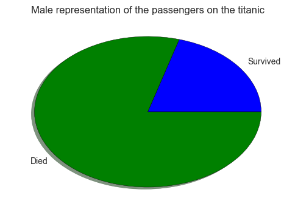

```python
surviveMen = [93, 360]
plt.legend()
plt.title('Male representation of the passengers on the titanic')
plt.pie(surviveMen, explode=None, labels=['Survived', 'Died'], colors=None, autopct=None, pctdistance=0.6, shadow=True, labeldistance=1.1, startangle=None, radius=1, counterclock=True, wedgeprops=None, textprops=None, center=(0, 0), frame=False, hold=None, data=None)
```

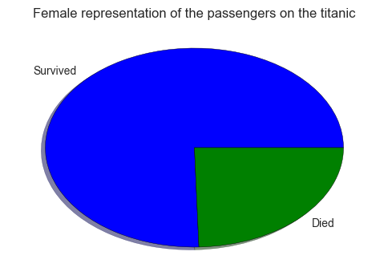

```python
surviveWomen = [197 , 64]
plt.legend()
plt.title('Female representation of the passengers on the titanic')
plt.pie(surviveWomen, explode=None, labels=['Survived', 'Died'], colors=None, autopct=None, pctdistance=0.6, shadow=True, labeldistance=1.1, startangle=None, radius=1, counterclock=True, wedgeprops=None, textprops=None, center=(0, 0), frame=False, hold=None, data=None)
```

These pie charts shows the skewed demographic of the ones who survived and the one who didn't. Among the ones that survived women had the highest chances. Among the ones that died men had the highest chance.

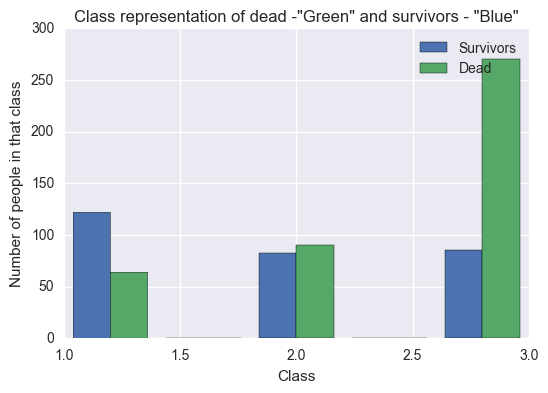

```python
counts, bins, bars = plt.hist((group1['Pclass'], group0['Pclass']),bins = 5, label=['Survivors','Dead'])
plt.xlabel('Class')
plt.ylabel('Number of people in that class')
plt.title(r'Class representation of dead -"Green" and survivors - "Blue"')
plt.legend()
```

People who survived seem to be in the categories that paid more. Approximately around 2X as much.

```python
print counts, bins, bars
```

```
[array([ 122.,    0.,   83.,    0.,   85.]), array([  64.,    0.,   90.,    0.,  270.])] [ 1.   1.4  1.8  2.2  2.6  3. ] <a list of 2 Lists of Patches objects>
```

```python
modTitanic['Fare'].max()
(0.527586206897 - 0.36) / 0.527586206897
```

```
0.3176470588241092
```

## Conclusions:

Q1. What demographics made it possible for the passengers to survive? A1. We were able to get qualitative understanding of the people who survived the disaster, It is pretty clear that being a young woman in the upper class having paid more have the highest rates of survival.

Q2. How did being a male or a female affect survival? What numbers of men and women survived? A2. We were also able to get quantitive values of the people who survived the disaster, mainly women survived more often and by significant margin. 197 of the 261 women in the data set survived, that's a survival chance of 75% when compared to a survival chance of 20.52% for men.

Q3. Were survivors from a higher class? A3. Indeed it was found that survivors on an average paid almost 2X as much compared to their dead counterparts to buy their tickets to survival into a higher class. People who survived has a class average of 1.8. Close to 2nd Class but also many in class 1.

### Possible Biases in the report :

Based on the data it is quite possible that there were a lot of mistakes in the age data and we had to take them out. Having this would have given me better predictions on age groups that were more likely to survive.

Also another thing that came across as strange was the fact that having siblings did not affect the chances of survival much, if one sibling was saved there was a good chance that the other would be saved as well considering rescue efforts are always targeted mainly at women and children first.

#### Future research :

I quite enjoyed investigating this data set, powerful results could be derived by simple but beautiful manipulation using easy stats. I was quite excited about how I could derive conclusions for the reason that Kate survived in the movie 'Titanic' was not just a chance but an actual fact that was highly probable. I also told all my friends at work about it.

Further reasearch would be machine learning based where given this information of the passengers I could predict wether they would survive or not. This would be done by training a machine learning algorithm on the exisiting data and then making predictions of survival on the test set.